# Modelling methylation profiles

Andreas C. Kapourani and Guido Sanguinetti

School of Informatics, University of Edinburgh, UK

c.a.kapourani@ed.ac.uk or kapouranis.andreas@gmail.com  
G.Sanguinetti@ed.ac.uk

21 June 2019

#### Abstract

Learn methylation profiles using basis function regression for different observation models. The inferred profiles can be used for downstream analysis, such as prediciting gene expression levels or clustering regions with similar methylation profiles. This vignette focuses on the functionality and the usage of the BPRMeth package. Mathematical details and modelling assumptions can be found in [2] and on the following link http://rpubs.com/cakapourani

#### Package

BPRMeth 1.11.0

# 1 Installation

```r
## try http:// if https:// URLs are not supported
if (!requireNamespace("BiocManager", quietly=TRUE))
    install.packages("BiocManager")
BiocManager::install("BPRMeth")

## Or download from Github repository
# install.packages("devtools")
devtools::install_github("andreaskapou/BPRMeth", build_vignettes = TRUE)
```

# 2 Introduction

DNA methylation is probably the best studied epigenomic mark, due to its well established heritability and widespread association with diseases. Yet its role in gene regulation, and the molecular mechanisms underpinning its association with diseases, are still imperfectly understood. While the methylation status of individual cytosines can sometimes be informative, several recent papers have shown that the functional role of DNA methylation is better captured by a quantitative analysis of the **spatial variation** of methylation across a genomic region.

The `BPRMeth` package is a probabilistic method to quantify explicit features of methylation profiles, in a way that would make it easier to formally use such profiles in downstream modelling efforts, such as predicting gene expression levels or clustering genomic regions according to their methylation profiles. The original implementation [1] has now been enhanced in two important ways: we introduced a fast, **variational inference** approach which enables the quantification of Bayesian posterior confidence measures on the model, and we adapted the method to use several observation models, making it suitable for a diverse range of platforms including **single-cell** analyses and **methylation arrays**. Technical details of the updated version are explained in [2].

In addition to being a flexible tool for methylation data, the proposed framework is in principle deployable to other measurements with a similar structure, and indeed the method was already used for single-cell **chromatin accessibility** data in [3].

# 3 Background

Mathematically, `BPRMeth` is based on a basis function generalised linear model. The basic idea is as follows: the methylation profile associated to a genomic region $D$ is defined as a (latent) function $f\colon D\rightarrow (0,1)$ which takes as input the genomic coordinate along the region and returns the propensity for that locus to be methylated. In order to enforce spatial smoothness, and to obtain a compact representation for this function in terms of interpretable features, we represent the profile function as a linear combination of basis functions

$$f(x)=\Phi\left(\mathbf{w}^Th(x)\right)$$

where $h(x)$ are the basis functions (Gaussian bells by default), and $\Phi$ is a probit transformation (Gaussian cumulative distribution function) needed in order to map the function output to the $(0,1)$ interval. The latent function is observed at specific loci through a noise model which encapsulates the experimental technology.

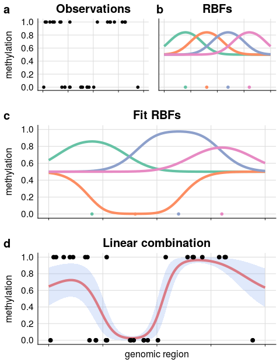

Figure 1: Illustration of the process for infering methylation profiles using the `BPRMeth` package

The optimal weight parameters $\mathbf{w}$ can be recovered either by Bayesian inference or maximum likelihood estimation, providing a set of quantitative features which can be used in downstream models: in [1] these features were used in a machine learning predictor of gene expression, and to cluster genomic regions according to their methylation profiles. Modelling details and mathematical derivations for the different models can be found online: http://rpubs.com/cakapourani.

# 4 Analysis Pipeline

The workflow diagram and functionalities of the `BPRMeth` package for analysis of methylation profiles are shown in Figure 2.

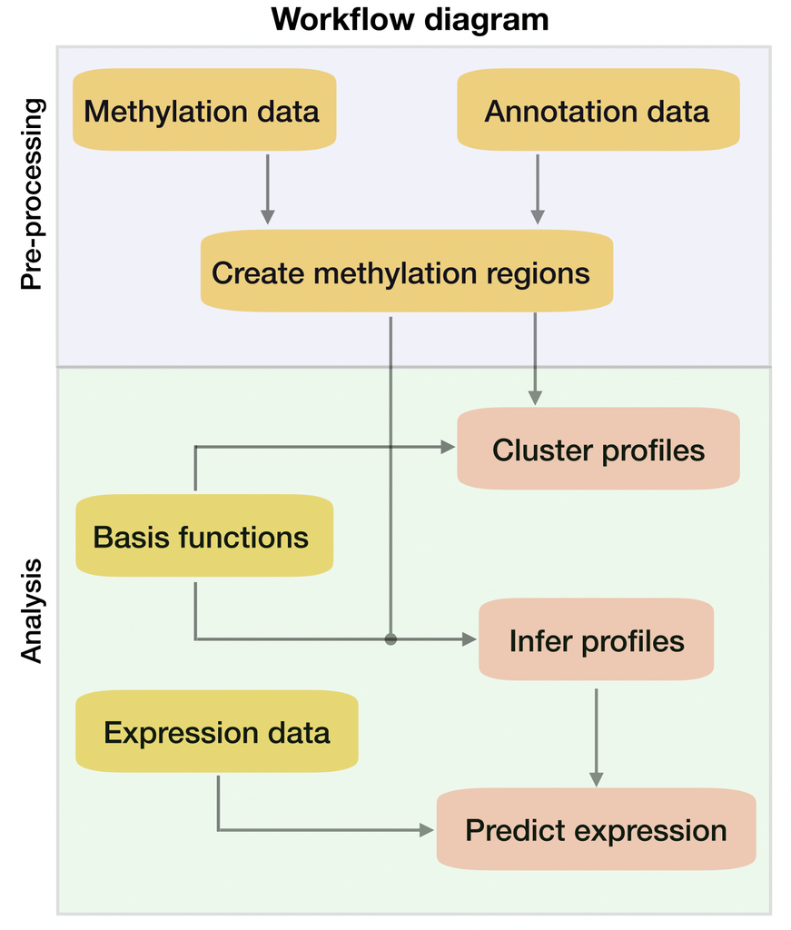

Figure 2: Workflow diagram and functionalities of the BPRMeth package

## 4.1 Sample data

To illustrate the functionality of the `BPRMeth` package we will use real datasets that are publicly available from the ENCODE project consortium [4]. More specifically we will focus on the K562 immortalized cell line, with GEO: GSE27584 for the bulk RRBS data and GEO: GSE33480 for the RNA-Seq data. We will use directly the preprocessed files, where we have kept only the protein coding genes, and for the purpose of this vignette we focus only on **chr12** and **chr13**. Full details of where to download the data and how to preprocess them are included in the Supplementary Material [1].

## 4.2 Load preprocessed data

Due to its general approach, `BPRMeth` can be used for a wide range of technologies such as array based, bulk sequencing (both RRBS and WGBS) and single cell sequencing methylation datasets. It is only required that the data are in the right format and we call the appropriate observation model depending on the type of technology. Since the encode data are generated from **bulk** RRBS experiments, the observation model for the `BPRMeth` package will be **Binomial**.

### 4.2.1 Methylation data

The `BPRMeth` package provides methods for reading files for methylation, annotation and expression data, however they do not cover all possible data formats available for describing biological datasets. The user can implement his own methods for reading files with different formats, provided that he can create an object similar to what is described below. First, we load the preprocessed methylation data as follows:

```r
library(BPRMeth)  # Load package
met_region <- encode_met
```

The `met_region` object contains the following important slots:

- `met`: A list containing the methylation region, where each element of the list is a different genomic region. More specifically, each methylation promoter region is an $L_{i} \times 3$ dimensional matrix, where $L_{i}$ denotes the number of CpGs found in region $i$. The columns contain the following information:
  - 1st column: Contains the locations of CpGs relative to central location. Note that the actual locations are scaled to the (-1, 1) region.
  - 2nd column: Contains the total reads of each CpG.
  - 3rd column: Contains the methylated reads each CpG.
- `anno`: Corresponding annotation data for each genomic region as `GRanges` object. The `anno` slot is only required for downstream analysis, e.g. to predict gene expression levels from methylation profiles, since we need to map the genomic regions with the gene IDs.

Now let’s observe the format of the `met_region` object. For example, we can access the $20^{th}$ promoter methylation region as follows

```r
head(met_region$met[[20]])
```

```
##         [,1] [,2] [,3]
## [1,] -0.8787   42    1
## [2,] -0.8779   42    0
## [3,] -0.8770   42    2
## [4,] -0.8759   42    0
## [5,] -0.8754   42    0
## [6,] -0.8667    9    1
```

Below are the annotation data

```r
head(met_region$anno)
```

```
## GRanges object with 6 ranges and 2 metadata columns:
##       seqnames          ranges strand |              id    centre
##          <Rle>       <IRanges>  <Rle> |     <character> <numeric>
##   [1]    chr12   562529-576529      + | ENSG00000139044    569529
##   [2]    chr12   745147-759147      + | ENSG00000177406    752147
##   [3]    chr12 1051888-1065888      - | ENSG00000002016   1058888
##   [4]    chr12 1696331-1710331      - | ENSG00000171823   1703331
##   [5]    chr12 2020870-2034870      - | ENSG00000151062   2027870
##   [6]    chr12 2897118-2911118      + | ENSG00000004478   2904118
##   -------
##   seqinfo: 2 sequences from an unspecified genome; no seqlengths
```

and the total number of genomic regions are

```r
NROW(met_region$anno)
```

```
## [1] 339
```

### 4.2.2 Read methylation and annotation data (Do not run)

In the previous section for simplicity we provided a pre-processed object which we then can directly use for inferring methylation profiles. The steps required to create this object are really simple and follow the diagram in Figure 2. First we need to read the methylation data using the `read_met` function. Also we need read annotation data using the `read_anno` file. **Note** that the annotation file can contain **any genomic context**: from promoters and gene bodies to enhancers, Nanog regulatory regions and CTCF regions; hence `BPRMeth` can be used for a plethora of analyses that want to take spatial genomic correlations into account. Finally, the `create_region_object` will create the methylation regions object which is the main object for storing methylation data. The following lines of code provide an example of creating this object ( **Do not run** )

```r
# Read bulk methylation data
met_dt <- read_met(file = "met_file", type = "bulk_seq")
# Read annotation file, which will create annotation regions as well
anno_dt <- read_anno(file = "anno_file")
# Create methylation regions that have CpG coverage
met_region <- create_region_object(met_dt = met_dt, anno_dt = anno_dt)
```

### 4.2.3 Expression data

If the goal is to relate methylation profiles to gene expression levels, we need also to store expression data. Again, here we have pre-processed expression data which can be loaded as follows

```r
expr <- encode_expr
```

The structure of the expression data is rather simple, it is a *data.table* with two columns as shown below

```r
head(expr)
```

```
##                 id      expr
## 1: ENSG00000230032 -3.321928
## 2: ENSG00000226210  3.833477
## 3: ENSG00000225143 -1.967380
## 4: ENSG00000234465 -3.321928
## 5: ENSG00000206114 -3.321928
## 6: ENSG00000235591 -3.321928
```

To create the expression data (which are $log_{2}$ transformed) we could call ( **Do not run** )

```r
# Read expression data and log2 transform them
expr <- read_expr(file = "expr_file", log2_transf = TRUE)
```

## 4.3 Create basis objects

For each genomic region, we will learn a methylation profile using the Binomial observation model with a specified number of **Radial Basis Functions (RBFs)** $M$. For a single input variable $x$, the RBF takes the form $h_{j}(x) = exp(-\gamma || x - \mu_{j} ||^2)$, where $\mu_{j}$ denotes the location of the $j^{th}$ basis function in the input space and $\gamma$ controls the spatial scale. The case when $M = 0$ is equivalent to learning the mena methylation rate for the given region (i.e. learn a constant function).

For our running example, we will create two RBF objects, one with 5 basis functions and the other with 0 basis functions denoting the mean methylation rate

```r
# Create RBF basis object with 5 RBFs
basis_profile <- create_rbf_object(M = 5)
# Create RBF basis object with 0 RBFs, i.e. constant function
basis_mean <- create_rbf_object(M = 0)
```

The `rbf` object contains information such as the centre locations $\mu_{j}$ and the value of the spatial scale parameter $\gamma$

```r
# Show the slots of the 'rbf' object
basis_profile
```

```
## $M
## [1] 5
##
## $mus
## [1] -0.6666667 -0.3333333  0.0000000  0.3333333  0.6666667
##
## $gamma
## [1] 6.25
##
## $eq_spaced_mus
## [1] TRUE
##
## $whole_region
## [1] TRUE
##
## attr(,"class")
## [1] "rbf"
```

The $\gamma$ is computed by the number of bases $M$, however the user can tune it according to his liking. Except from RBF basis, the `BPRMeth` pacakge provides **polynomial** and **Fourier** basis functions which can be created with the `create_polynomial_object` and `create_fourier_object` functions, respectively.

## 4.4 Inferring methylation profiles

Learning the methylation profiles is equivalent to inferring the model parameters $\mathbf{W}$ of the **generalised linear regression** model. These parameters can be considered as the extracted features which quantitate precisely notions of shape of a methylation profile.

For performing parameter inference, the `BPRMeth` package is enhanced to provide both maximum likelihood estimation and Bayesian inference for the parameters. Specifically, for Bayesian estimation it provides an efficient **mean-field variational inference (Variational Bayes)** and a **Gibbs sampling** algorithm. For computational efficiency one should choose the VB implementation (Note that for Beta observation models, one should use MLE to infer the profiles, since currently the package does not provide Bayesian treatment for Beta likelihood).

To infer the methylation profiles using **VB** we need to call the `infer_profiles_vb` function

```r
fit_profiles <- infer_profiles_vb(X = met_region$met, model = "binomial",
                                basis = basis_profile, is_parallel = FALSE)

fit_mean <- infer_profiles_vb(X = met_region$met, model = "binomial",
                              basis = basis_mean, is_parallel = FALSE)
```

This results in a `infer_profiles` object whose most important slot is the inferred weight matrix `W`, below we show the structure of the `fit_profiles` object

```r
# Show structure of fit_profiles object
str(fit_profiles, max.level = 1)
```

```
## List of 9
##  $ W            : num [1:339, 1:6] 0.546 6.128 -0.235 -0.389 -0.172 ...
##   ..- attr(*, "dimnames")=List of 2
##  $ W_Sigma      :List of 339
##  $ alpha        : num [1:339, 1] 3.5 3.5 3.5 3.5 3.5 3.5 3.5 3.5 3.5 3.5 ...
##  $ beta         : num [1:339, 1] 35 35 3.887 1.03 0.393 ...
##  $ basis        :List of 5
##   ..- attr(*, "class")= chr "rbf"
##  $ nll_feat     : num [1:339, 1] 61.6 101 88.9 90 30.2 ...
##  $ rmse_feat    : num [1:339, 1] 0.1055 0.0922 0.2108 0.1311 0.2783 ...
##  $ coverage_feat: int [1:339, 1] 29 26 17 41 13 47 16 16 38 21 ...
##  $ lb_feat      : num [1:339, 1] -506 -185.3 -149.6 -229 -98.7 ...
##  - attr(*, "class")= chr [1:3] "infer_profiles_vb_binomial" "infer_profiles_vb" "infer_profiles"
```

Below we show an example promoter region together with the fitted methylation profiles, where the points represent the DNA methylation level of each CpG site. The shape of the methylation profiles is captured by the blue curve, whereas the red line denotes the mean methylation rate

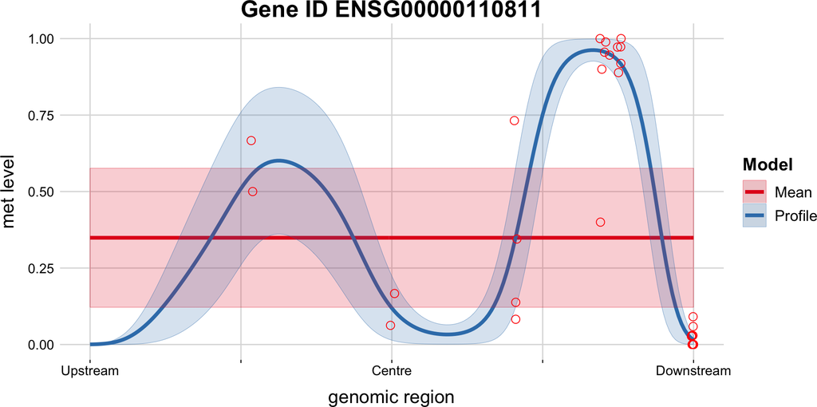

Figure 3: Inferring methylation profiles  
Methylation pattern for specific genomic region over +/-7kb promoter region.

```r
# Choose promoter region 21 -> i.e. LEPREL2 gene
gene_id <- met_region$anno$id[21]
p <- plot_infer_profiles(region = 21, obj_prof = fit_profiles,
                         obj_mean = fit_mean, obs = met_region$met,
                         title = paste0("Gene ID ", gene_id))
print(p)
```

## 4.5 Applications

### 4.5.1 Predicting gene expression

To quantitatively predict expression at each region, we construct a regression model by taking as input the higher-order methylation features learned from the `infer_profiles_vb`. In addition to these features, we consider two supplementary sources of information: (1) the goodness of fit in RMSE and (2) the CpG density. For our analysis an SVM regression model is considered. We will use $70\%$ of the data for training, and we will test the model’s performance on the remaining $30\%$.

All the aforementioned steps are assembled in the `predict_expr` wrapper function:

```r
# Set seed for reproducible results
set.seed(22)
# Perform predictions using methylation profiles
pred_profile <- predict_expr(prof_obj = fit_profiles, expr = expr,
                             anno = met_region$anno, model_name = "svm",
                             fit_feature = "RMSE", cov_feature = TRUE,
                             is_summary = FALSE)
# Perform predictions using mean methylation rate
pred_mean <- predict_expr(prof_obj = fit_mean, expr = expr,
                          anno = met_region$anno, model_name = "svm",
                          is_summary = FALSE)
```

```r
print(paste("Profile r: ", round(pred_profile$test_errors$pcc, 2)))
```

```
## [1] "Profile r:  0.66"
```

```r
print(paste("Mean r:", round(pred_mean$test_errors$pcc, 2)))
```

```
## [1] "Mean r: 0.44"
```

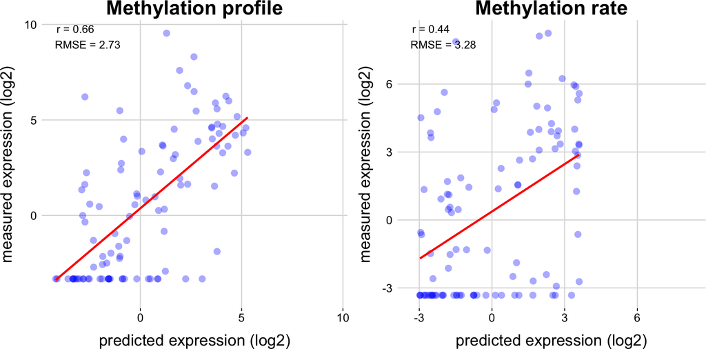

Figure 4: Relationship between DNA methylation patterns and gene expression  
Scatter plots of predicted versus measured (log2-transformed) gene expression values using profiles (left) and rates (right); each shaded blue dot represents a different gene, The red line indicates the linear fit between the predicted and measured expression values.

```r
g1 <- plot_predicted_expr(pred_obj = pred_profile,
                          title = "Methylation profile")
g2 <- plot_predicted_expr(pred_obj = pred_mean,
                          title = "Methylation rate")
g <- cowplot::plot_grid(g1, g2, ncol = 2, nrow = 1)
print(g)
```

### 4.5.2 Clustering methylation profiles

Another application of the `BPRMeth` model is to use the higher-order methylation features to cluster DNA methylation patterns across genomic regions and examine whether distinct methylation profiles are associated to different gene expression levels. To cluster methylation profiles, a mixture modelling approach is considered and we perform inference either via EM algorithm (MLE estimates) or using the mean-field variational inference (Variational Bayes VB) model. In this example we will use the VB model to perform variational inference.

The `BPRMeth` package provides the `cluster_profiles_vb` function for performing Bayesian clustering, where the user needs to provide the number of clusters $K$, the methylation regions $X$, the observation model and a basis object. For efficiency we run on 20 VB iterations.

```r
# Set seed for reproducible results
set.seed(12)
# Create basis object
basis_obj <- create_rbf_object(M = 3)
# Set number of clusters K
K <- 4
# Perform clustering
cl_obj <- cluster_profiles_vb(X = met_region$met, K = K, model = "binomial",
                              alpha_0 = .5, beta_0 = .1,
                              basis = basis_obj, vb_max_iter = 20)
```

Figure 5 shows the fitted methylation profiles for each cluster.

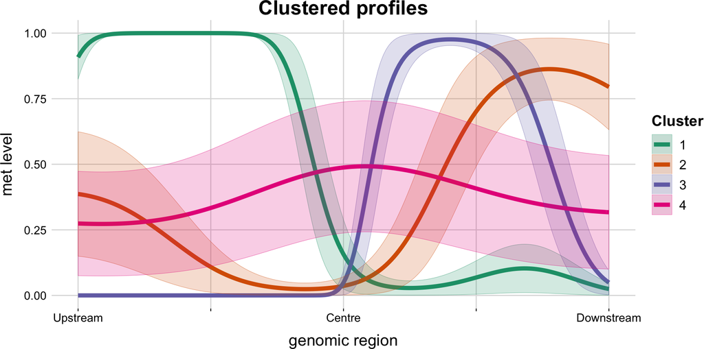

Figure 5: Clustering methylation profiles across promoter-proximal regions

```r
cluster_plot <- plot_cluster_profiles(cluster_obj = cl_obj)
print(cluster_plot)
```

## 4.6 Beta methylation profiles

The structure of the package makes it straighforward to work with methylation data generated from different technologies. For example, with **methylation array** data, the most common approach is to use the Beta distribution to capture the methylation level from the array experiment. Below we provide a minimal analysis step for inferring methylation profiles on synthetic data; note that we just need to define that `model = beta`. (In some cases, researchers work with M-values, where they transform the Beta values to $(-\inf, \inf)$, i.e. they make them Gaussian random variables, if that is the case the `BPRMeth` package can handle this by setting `model = gaussian`.) **Note** that for the Beta model, we currently provide only maximum likelihood estimation (MLE).

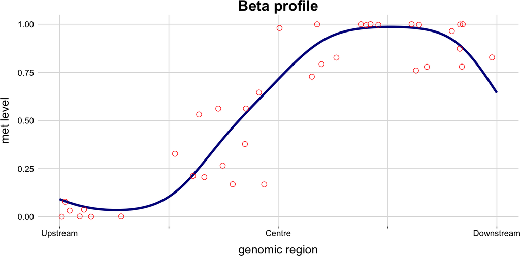

```r
basis_obj <- create_rbf_object(M = 5)
# Infer beta profiles
beta_prof <- infer_profiles_mle(X = beta_data, model = "beta",
                                basis = basis_obj, is_parallel = FALSE)
p <- plot_infer_profiles(region = 15, obj_prof = beta_prof,
                         obs = beta_data, title = "Beta profile")
print(p)
```